# NYC Citi Bikes

```
##     bike_id       start_time                    stop_time
##  33571  : 647   Min.   :2018-01-01 21:19:01   Min.   :2018-01-01 21:20:41
##  29477  : 571   1st Qu.:2018-05-22 06:48:01   1st Qu.:2018-05-22 06:52:11
##  26301  : 553   Median :2018-07-24 10:47:26   Median :2018-07-24 10:51:51
##  33557  : 546   Mean   :2018-07-16 21:20:18   Mean   :2018-07-16 21:32:34
##  29522  : 479   3rd Qu.:2018-09-11 18:33:52   3rd Qu.:2018-09-11 18:36:50
##  29506  : 469   Max.   :2018-12-31 09:08:35   Max.   :2018-12-31 09:13:12
##  (Other):1003
##  start_station    start_lat       start_long      end_station      end_lat
##  3186   : 434   Min.   :40.71   Min.   :-74.09   3186   : 577   Min.   :40.70
##  3203   : 278   1st Qu.:40.72   1st Qu.:-74.05   3183   : 291   1st Qu.:40.72
##  3195   : 250   Median :40.72   Median :-74.04   3203   : 253   Median :40.72
##  3183   : 221   Mean   :40.72   Mean   :-74.05   3195   : 214   Mean   :40.72
##  3202   : 181   3rd Qu.:40.73   3rd Qu.:-74.04   3202   : 211   3rd Qu.:40.73
##  3639   : 146   Max.   :40.75   Max.   :-74.03   3639   : 137   Max.   :40.76
##  (Other):2758                                    (Other):2585
##     end_long              type        birth_year       gender
##  Min.   :-74.10   Customer  : 315   Min.   :1887   Unknown: 269
##  1st Qu.:-74.05   Subscriber:3953   1st Qu.:1973   Male   :3069
##  Median :-74.04                     Median :1983   Female : 930
##  Mean   :-74.05                     Mean   :1980
##  3rd Qu.:-74.04                     3rd Qu.:1988
##  Max.   :-74.00                     Max.   :1999
##
```

```
## [1] "start_time"
```

# Background

Citi Bike is New York City’s bike share system, and the largest in the nation. Citi Bike launched in May 2013 and has become an essential part of our transportation network. It’s fun, efficient and affordable – not to mention healthy and good for the environment.

Fig1 shows the current bike stations from the data set provided.

Fig1 Bike Stations

[interactive chart not shown]

## Aim of report

The report aims to answer a number of business questions namely:

1. What is the pattern of bike hires over time (e.g. within a year, month, week, or day)?
2. Do bike hire patterns differ between bike rider demographics? (e.g. gender, type of trip, age)
3. Any other insights?

## Data used

The report draws from data collected through the system for 2018. All names of users have been anonymised in line with current guidelines and ethical considerations.

## Data Cleaning

Data cleaning consisted initially of converting to suitable format to produce some summary statistics. Secondly this was further wrangled to allow for time series manipulation and visualisation of the findings.

## Report findings

The following is split between each of the business questions:

### What is the pattern of bike hires over time (e.g. within a year, month, week, or day)?

From the graphs below it can be seen that the basic useage is not only seasonal but also certain during the weekdays with rush hours typically having more useage.

Fig2 Seasonality

It can be seen that the summer months attract more bike usage as expected with higher temperatures being experienced.

```r
bike_month <- bikes %>%
  index_by(month = month(start_time, label = TRUE)) %>%
  summarise(count = n())

bike_month
```

| month | count |
| --- | --- |
| Jan | 132 |
| Feb | 112 |
| Mar | 173 |
| Apr | 326 |
| May | 459 |
| Jun | 498 |
| Jul | 637 |
| Aug | 728 |
| Sep | 432 |
| Oct | 416 |

[output cut: 2 more lines]

[figure not shown]

Fig3 Days in week

Again from the graph below it can be seen that the weekdays experience a marginally higher usage.

```r
bike_day <- bikes %>%
  index_by(day = wday(start_time, label= TRUE)) %>%
  summarise(count = n())

bike_day
```

| day | count |
| --- | --- |
| Sun | 453 |
| Mon | 628 |
| Tue | 720 |
| Wed | 651 |
| Thu | 635 |
| Fri | 658 |
| Sat | 523 |

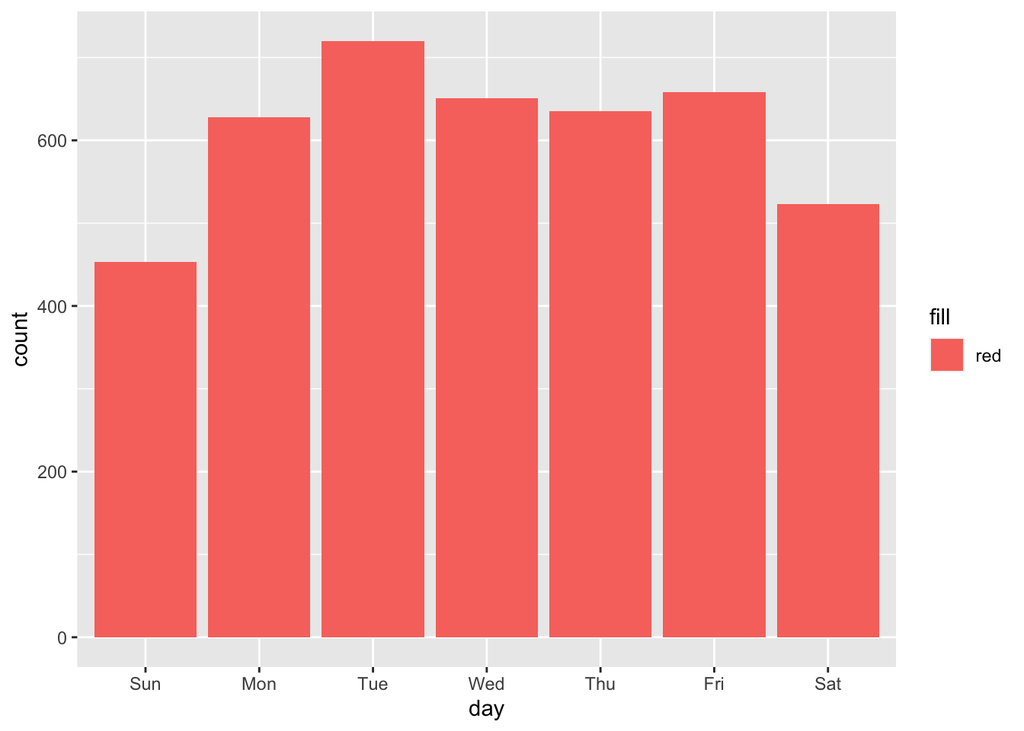

```r
bike_day %>%
  ggplot() +
  aes(x = day, y = count, fill = "red") +
  geom_col()
```

### Do bike hire patterns differ between bike rider demographics? (e.g. gender, type of trip, age)

It can be seen that ther is a difference between gender usage. Typically more males are using the scheme.

## Conclusion and next steps

While the scheme is a success for usage, there is room to improve for inclusiveness and reason for trips.

```r
bikes
```

| bike_id | start_time | stop_time | start_station | start_lat | start_long | end_station | end_lat | end_long | type | birth_year | gender |
| --- | --- | --- | --- | --- | --- | --- | --- | --- | --- | --- | --- |
| 26301 | 2018-02-26 19:11:03 | 2018-02-26 19:15:40 | 3186 | 40.71959 | -74.04312 | 3203 | 40.72760 | -74.04425 | Subscriber | 1986 | Male |
| 26301 | 2018-02-27 07:52:49 | 2018-02-27 07:58:13 | 3203 | 40.72760 | -74.04425 | 3202 | 40.72722 | -74.03376 | Subscriber | 1979 | Male |
| 26301 | 2018-02-27 12:03:27 | 2018-02-27 12:04:54 | 3202 | 40.72722 | -74.03376 | 3638 | 40.72429 | -74.03548 | Subscriber | 1963 | Male |
| 26301 | 2018-02-27 13:53:51 | 2018-02-27 14:21:04 | 3638 | 40.72429 | -74.03548 | 3638 | 40.72429 | -74.03548 | Subscriber | 1984 | Male |
| 26301 | 2018-02-27 14:30:42 | 2018-02-27 14:33:11 | 3638 | 40.72429 | -74.03548 | 3187 | 40.72112 | -74.03805 | Subscriber | 1980 | Male |
| 26301 | 2018-02-27 16:31:04 | 2018-02-27 16:33:27 | 3187 | 40.72112 | -74.03805 | 3638 | 40.72429 | -74.03548 | Subscriber | 1980 | Male |
| 26301 | 2018-02-27 17:37:12 | 2018-02-27 17:40:49 | 3638 | 40.72429 | -74.03548 | 3639 | 40.71925 | -74.03423 | Subscriber | 1989 | Male |
| 26301 | 2018-02-27 17:49:10 | 2018-02-27 17:55:03 | 3639 | 40.71925 | -74.03423 | 3202 | 40.72722 | -74.03376 | Subscriber | 1962 | Male |
| 26301 | 2018-02-27 18:21:57 | 2018-02-27 18:25:18 | 3202 | 40.72722 | -74.03376 | 3638 | 40.72429 | -74.03548 | Subscriber | 1992 | Male |
| 26301 | 2018-02-27 22:08:55 | 2018-02-27 22:28:42 | 3638 | 40.72429 | -74.03548 | 3281 | 40.74591 | -74.05727 | Subscriber | 1981 | Male |

[output cut: 4258 more lines]

Average journey length for each station

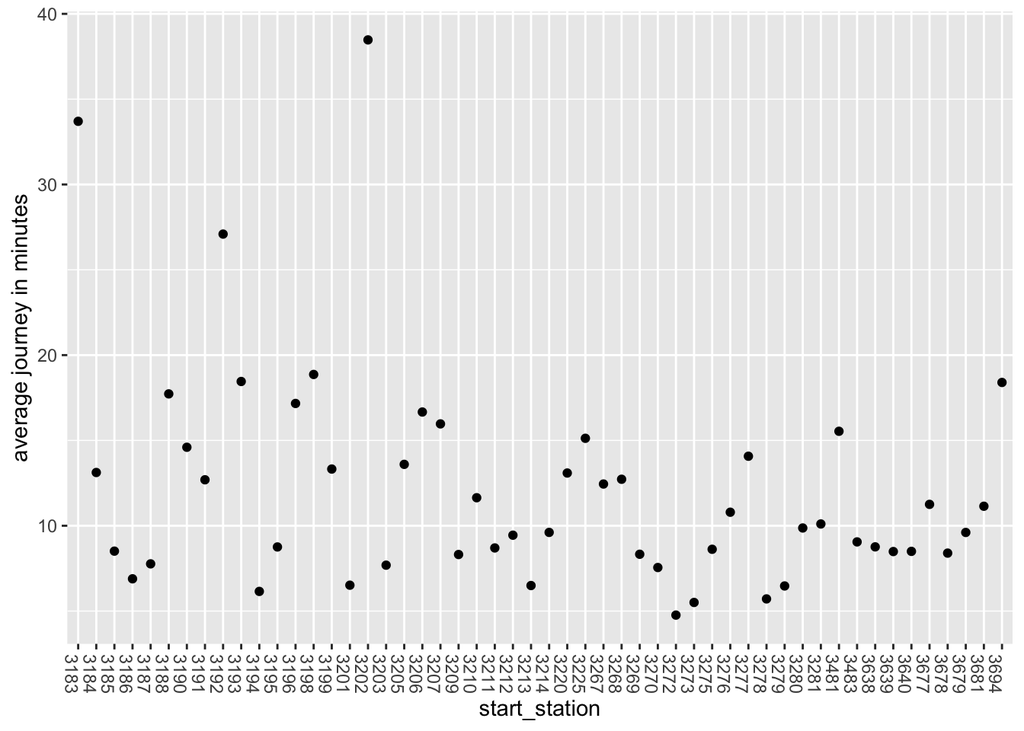

```r
bikes %>%
  as_tibble() %>%
  group_by(start_station) %>%
  mutate(journey = stop_time - start_time) %>%
  select(journey) %>%
 summarise(mean_journey = mean(journey)) %>%
  ggplot() +
  aes(x = start_station, y = mean_journey) +
  theme(axis.text.x = element_text(angle = -90))+
  ylab("average journey in minutes") +
  geom_point()
```

most used stations

```r
bike_df <- bikes %>% as_tibble()
```

```r
most_used <- bikes %>%
  as_tibble() %>%
  group_by(start_station) %>%
  summarise(count = n()) %>%
  arrange(desc(count)) %>%
  head(1)

most_used
```

| start_station | count |
| --- | --- |
| 3186 | 434 |

counts by year

```r
bikes %>%
  index_by(year = year(start_time)) %>%
  summarise(count = n())
```

| year | count |
| --- | --- |
| 2018 | 4268 |

month count to show seasonality - clearly the summer months is when they are used much more frequently.

```r
bike_month <- bikes %>%
  index_by(month = month(start_time, label = TRUE)) %>%
  summarise(count = n())

bike_month
```

| month | count |
| --- | --- |
| Jan | 132 |
| Feb | 112 |
| Mar | 173 |
| Apr | 326 |
| May | 459 |
| Jun | 498 |
| Jul | 637 |
| Aug | 728 |
| Sep | 432 |
| Oct | 416 |

[output cut: 2 more lines]

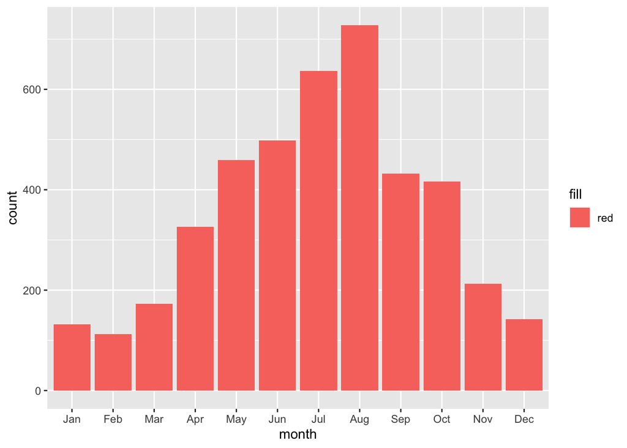

```r
bike_month %>%
  ggplot() +
  aes(x = month, y = count, fill = "red") +
  geom_col()
```

day analysis to see if any days are more favoured

```r
bike_day <- bikes %>%
  index_by(day = wday(start_time, label= TRUE)) %>%
  summarise(count = n())

bike_day
```

| day | count |
| --- | --- |
| Sun | 453 |
| Mon | 628 |
| Tue | 720 |
| Wed | 651 |
| Thu | 635 |
| Fri | 658 |
| Sat | 523 |

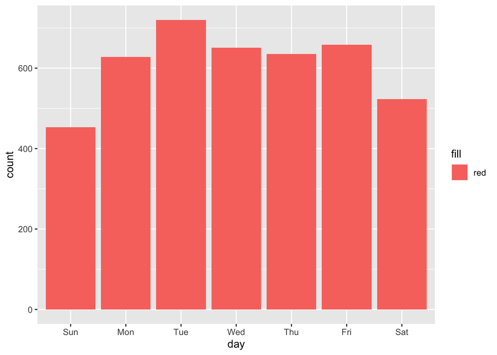

```r
bike_day %>%
  ggplot() +
  aes(x = day, y = count, fill = "red") +
  geom_col()
```

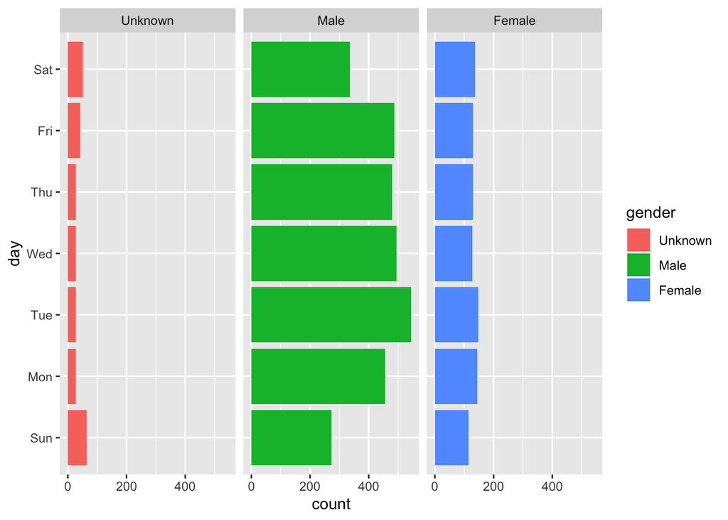

```r
bikes %>%
  index_by(day = wday(start_time, label = TRUE)) %>%
  ggplot() +
  aes(x = day, fill = gender) +
  geom_bar() +
  facet_wrap(~gender)+
  coord_flip()
```

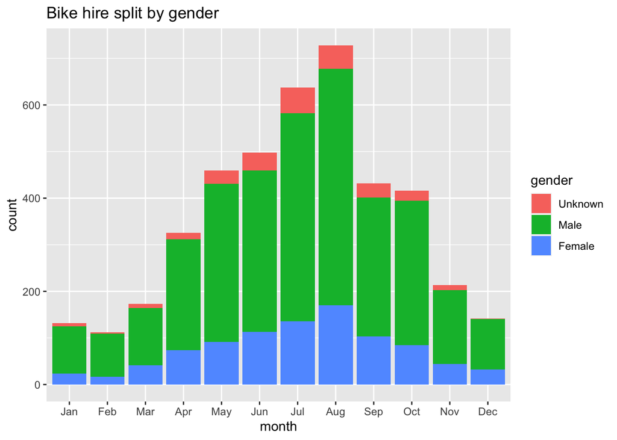

```r
bikes %>%
  index_by(month = month(start_time, label = TRUE) ) %>%
  ggplot() +
  aes(x = month, fill = gender) +
  geom_bar() +
  ggtitle("Bike hire split by gender")
```

bike useage over 24hrs

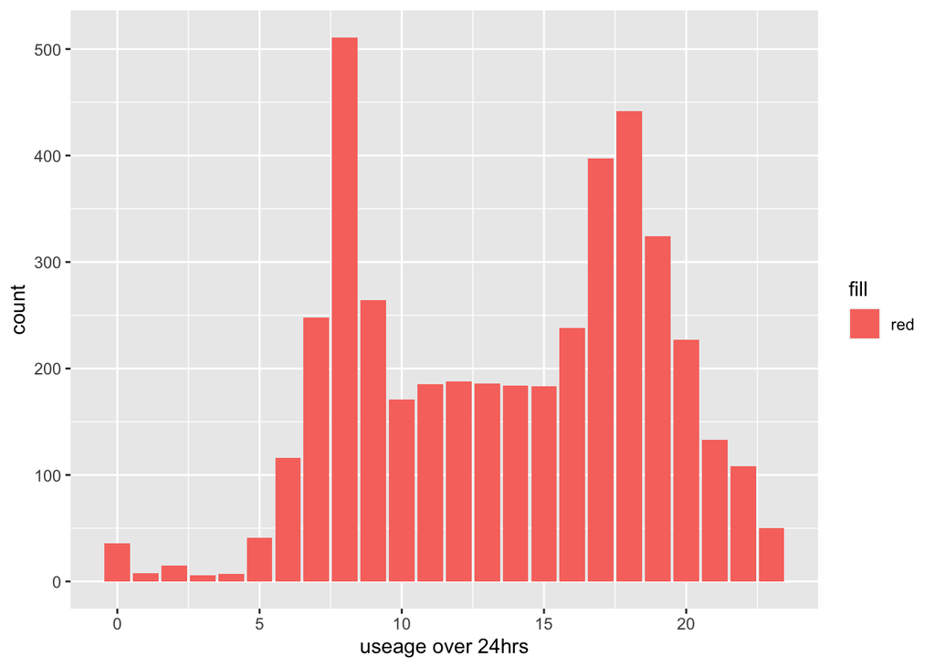

```r
bikes %>%
  index_by(time = hour(start_time)) %>%
  ggplot() +
  aes(x = time, fill = "red") +
  geom_bar() +
  xlab("useage over 24hrs")
```

Bike Stations

```r
bikes_clean <- bikes %>%
  mutate_at(vars(start_lat, start_long, end_lat, end_long), as.numeric)
```

```r
leaflet(bikes_clean) %>%
  addTiles() %>%
  addMarkers(lng = ~start_long, lat = ~start_lat)
```

[interactive chart not shown]

Start points

```r
leaflet(bikes_clean) %>%
  addTiles() %>%
  addMarkers(lng = ~start_long, lat = ~start_lat, clusterOptions = markerClusterOptions())
```

[interactive chart not shown]

end points

```r
leaflet(bikes_clean) %>%
  addTiles() %>%
  addMarkers(lng = ~end_long, lat = ~end_lat, clusterOptions = markerClusterOptions())
```

[interactive chart not shown]